# Lo que nos dijeron los datos

Retroalimentación general · Entrega 2 — Los datos del problema

Juan Carlos Muñoz-Mora, Ph.D.

Gestión de la Información y Gobernanza de Datos — Universidad EAFIT

22 de septiembre de 2026

## ¿Tus datos dicen lo que crees que dicen?

## Subieron, y bastante

3,60

Entrega 1

4,04

**Entrega 2**

+0,44

de mejora

**De los 86 puntos que les pedí corregir, 49 quedaron corregidos** y 31 a medio camino.

## Dónde está ahora el eslabón débil

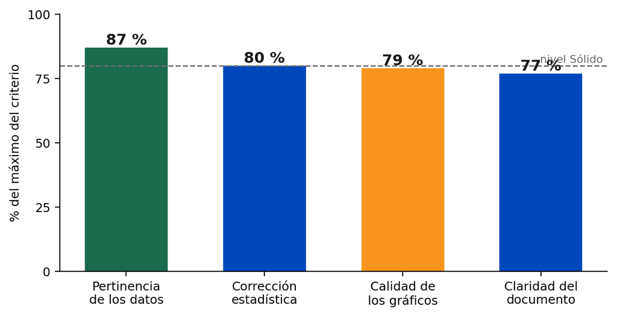

## Lo que salió bien

- Fueron a la **fuente primaria**: TerriData, SIVICAP, SIEDCO, INS, fichas BPIN, planes de desarrollo
- Hay Excel con **fórmulas vivas**, no números pegados: uno del grupo tiene 860 fórmulas sin un solo error
- Varios **documentaron la brecha** cuando el dato no existía, en vez de inventarlo
- Alguien construyó una hoja que **amarra cada cifra del memo a su celda**

## Tres formas de que un gráfico mienta

## 1 · El rango que se estiró de más

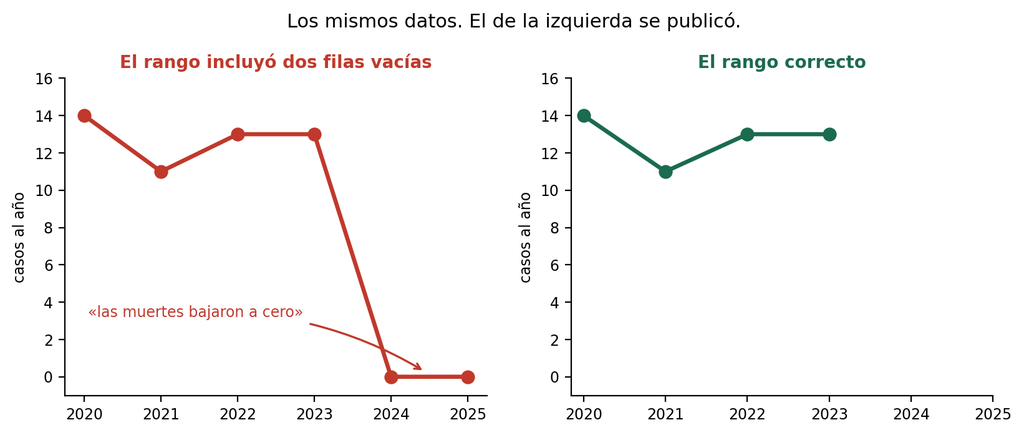

## 2 · Dos puntos no son una tendencia

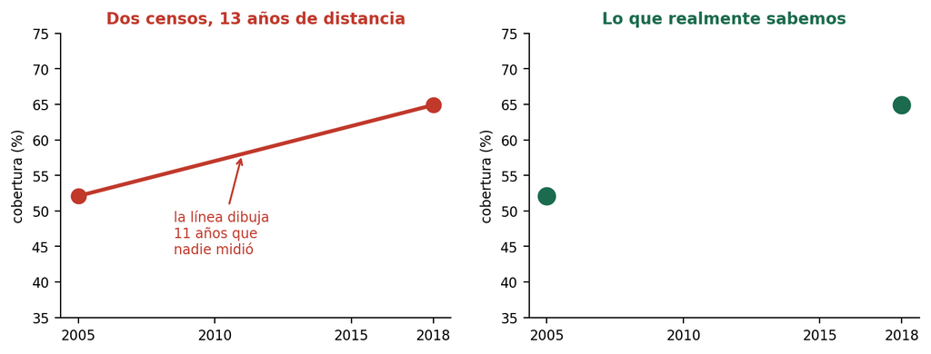

## 3 · El rótulo que no corresponde a la barra

En una entrega, las **barras** venían de una hoja y los **nombres** de otra, en distinto orden.

La barra más alta quedó con el nombre equivocado — y ese gráfico era el central de la infografía, contradiciendo su propio memo.

## Las medidas también engañan

## El promedio de porcentajes

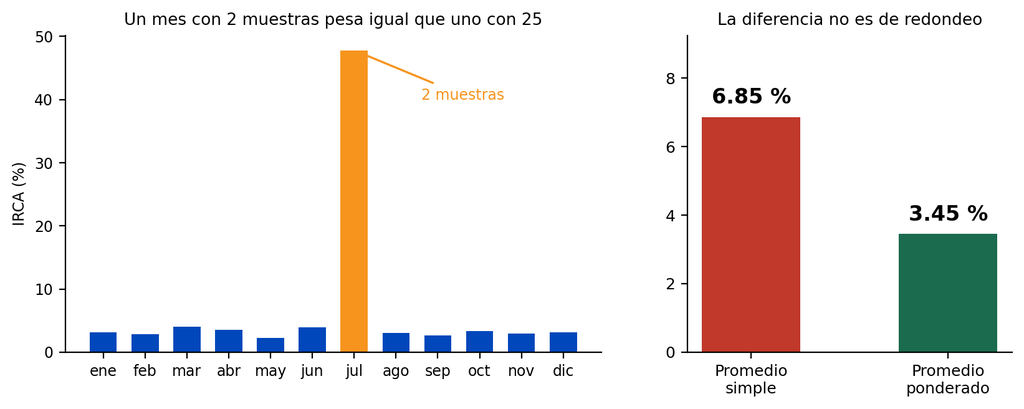

## Cuando solo hay dos años

Con **n = 2**:

- la **mediana** es igual al promedio, siempre
- la **correlación** da 1 o −1, siempre
- la **desviación** no dice casi nada

No es un hallazgo.  
Es aritmética.

Si la serie es corta, **dígalo** y use el dato como lo que es: una foto, no una película.

## Hablemos de la inteligencia artificial

## Lo primero: casi todos declararon

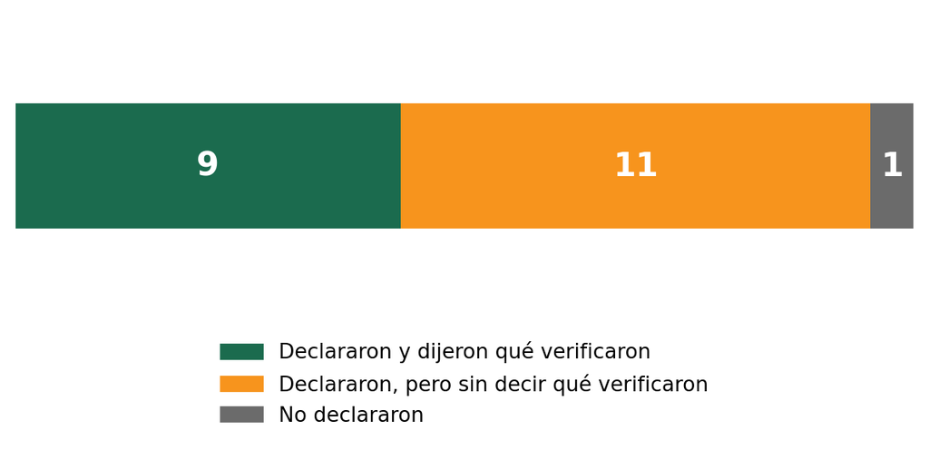

## Lo que casi siempre falta

La declaración pide **tres** cosas:

1 · qué herramienta 2 · para qué 3 · qué verificaste

Once entregas se quedaron en las dos primeras.

## La trampa más fina de todas

«Verifiqué todas las cifras contra el archivo fuente.»

Pero el archivo fuente **lo descargó la IA**.

Comparar contra lo que la herramienta le entregó **no verifica nada**. Es circular.

## Verificar es esto

1. Abrir **la página de la entidad**, no la respuesta del chat
2. Buscar **su** municipio, **su** indicador, **su** año
3. Comparar con lo que tiene en el Excel
4. Si no coincide, **gana la fuente**
5. Dejar el **enlace y la fecha de descarga** al lado del dato

## Dónde se rompen más las cifras

En la infografía

Es la pieza que **sale a circular** — y la que menos se revisa.

En una entrega, **cuatro** cifras de la infografía contradecían su propio Excel.

## Manos a la obra

## Actividad · 15 minutos, en parejas

1. Abre **tu infografía** y señala la cifra más importante
2. Con el computador, **ve a la fuente** y búscala
3. ¿Coincide? ¿Está el año? ¿Está la unidad?
4. Tu pareja revisa **tu gráfico**: ¿el rango incluye filas vacías? ¿los rótulos corresponden?

## Para la Entrega 3

- Cada cifra con **enlace y fecha de descarga** al lado
- Gráficos: **revisar el rango** antes de exportar
- Porcentajes y tasas: **ponderar**, nunca promediar directo
- La declaración de IA con las **tres** partes
- Los puntos de *“Qué corregir”* de su Word: **se revisan uno por uno**

## La idea de hoy

Un dato que no se puede rastrear hasta su fuente  
no es evidencia: es una opinión con números.

## Sigamos la conversación

[figure not shown]

LinkedIn

[figure not shown]

Escríbeme

jmunozm1@eafit.edu.co · jcmunozmora.github.io